# R Notebook

## **Palmer Penguins Dataset**

The **`palmerpenguins`** dataset has become a popular alternative to the widely-used **`iris`** dataset for data visualization and teaching statistical concepts.

### **Variables:**

1. **species**:
   - **Type**: Factor
   - **Levels**:
     - Adelie
     - Chinstrap
     - Gentoo
2. **island**:
   - **Type**: Factor
   - **Levels**:
     - Biscoe
     - Dream
     - Torgersen
3. **bill_length_mm**:
   - **Type**: Numeric
   - **Description**: Length of the penguin’s bill in millimeters.
4. **bill_depth_mm**:
   - **Type**: Numeric
   - **Description**: Depth of the penguin’s bill in millimeters.
5. **flipper_length_mm**:
   - **Type**: Numeric
   - **Description**: Length of the penguin’s flippers in millimeters.
6. **body_mass_g**:
   - **Type**: Numeric
   - **Description**: Penguin’s body mass in grams.
7. **sex**:
   - **Type**: Factor
   - **Description**: Sex of the penguin.
8. **year**:
   - **Type**: Integer
   - **Description**: Year of observation.

### **Usage in R:**

To use the dataset in R, follow the steps:

```r
install.packages("palmerpenguins")
library(palmerpenguins)
data("penguins")
head(penguins)
```

| species | island | bill_length_mm | bill_depth_mm | flipper_length_mm | body_mass_g | sex | year |
| --- | --- | --- | --- | --- | --- | --- | --- |
| Adelie | Torgersen | 39.1 | 18.7 | 181 | 3750 | male | 2007 |
| Adelie | Torgersen | 39.5 | 17.4 | 186 | 3800 | female | 2007 |
| Adelie | Torgersen | 40.3 | 18.0 | 195 | 3250 | female | 2007 |
| Adelie | Torgersen | NA | NA | NA | NA | NA | 2007 |
| Adelie | Torgersen | 36.7 | 19.3 | 193 | 3450 | female | 2007 |
| Adelie | Torgersen | 39.3 | 20.6 | 190 | 3650 | male | 2007 |

### **Advantages of Using `palmerpenguins` over `iris`:**

- **Diversity of Data Types**: The dataset includes continuous, categorical, and ordinal variables.
- **Missing Data**: Contains some missing values, making it representative of real-world datasets.
- **Ethical Considerations**: Avoids controversies associated with Ronald A. Fisher and the **`iris`** dataset.
- **Engagement**: Penguins are engaging and charismatic!

## Plotting in R Notebook

Let us create the same plot we did in the Simple R Script few days ago.

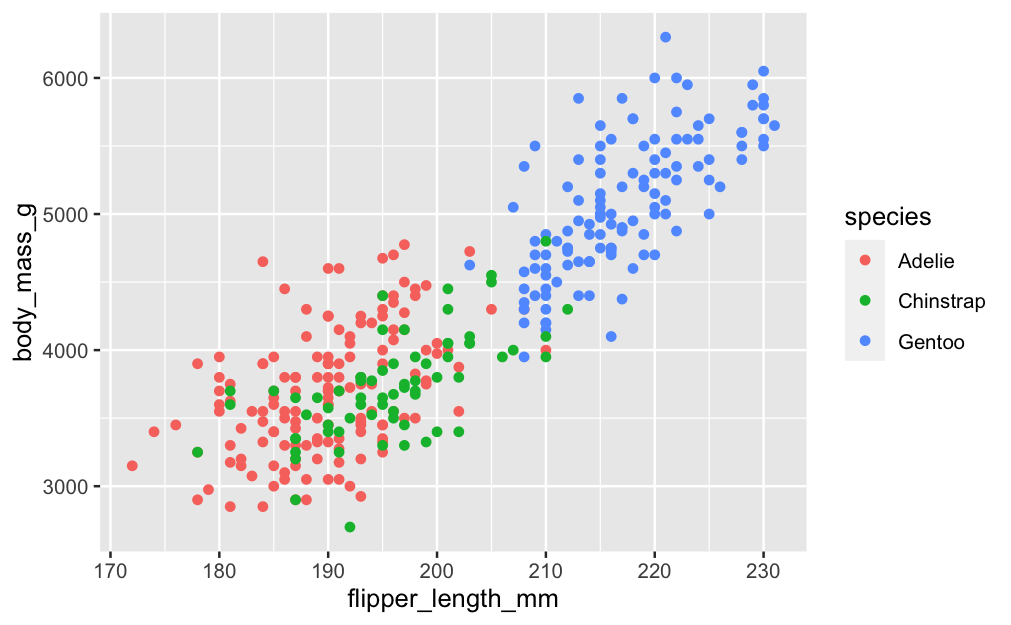

```r
install.packages("tidyverse")
library(ggplot2)

ggplot(
  data = penguins,
  mapping = aes(x = flipper_length_mm,
                y = body_mass_g,
                color = species)
) +
  geom_point()
```

## TODO

Please save your updates and Preview it.